# Genomic Annotation of Twist bed file with target regions

Gaja Matassa

Date: September 27, 2024

# 1. Environment setting

```r
library(GenomicRanges)
library(plyranges)
library(biomaRt)
library(ChIPseeker)
library(org.Hs.eg.db)
library(annotatr)
```

Making txdb object from GTF file

```r
OutputFolder <- params$OutputFolder

GTFFile <- "~/DataDir/3.TwistBedAnn/Input/gencode.v35.annotation.gtf.gz"
txdb_v35 <- GenomicFeatures::makeTxDbFromGFF(GTFFile, format="gtf")
## Import genomic features from the file as a GRanges object ... OK
## Prepare the 'metadata' data frame ... OK
## Make the TxDb object ...
## Warning in .get_cds_IDX(mcols0$type, mcols0$phase): The "phase" metadata column contains non-NA values for features of type stop_codon. This information was
## ignored.
## OK
```

Importing bed file with regions targeted by Twist kit

```r
TwistBed <- params$TwistBed
Twistbed <- as.data.frame(read.table(TwistBed,header = FALSE, sep="\t",stringsAsFactors=FALSE, quote=""))
```

```r
colnames(Twistbed) <- c("chr", "start", "end", "ann")
```

Remember that position form bedGraph files are 0-based while R works with 1-based position and therefore also the packages we will go to use, this is the reason why I set `starts.in.df.are.0based = TRUE` in creating the GRanges objects, it converts 0-based to 1-based coordinates.

```r
Twist_Granges <- makeGRangesFromDataFrame(Twistbed, keep.extra.columns = TRUE,
                                                start.field = "start", end.field = "end", starts.in.df.are.0based = TRUE)
```

# 2. Genetic annotation and visualization with **`ChIPseeker`**

DMRs are now annotated to their associated genes and genomic regions using the `annotatePeaks` function of the `ChIPseeker`R package, using a TxDb object. The [`GenomicFeatures`](https://bioconductor.org/packages/devel/bioc/vignettes/GenomicFeatures/inst/doc/GenomicFeatures.html) package uses `TxDb` objects to store transcript metadata. This class maps the 5’ and 3’ untranslated regions (UTRs), protein coding sequences (CDSs) and exons for a set of mRNA transcripts to their associated genome. All `TxDb` objects are backed by a SQLite database that manages genomic locations and the relationships between pre-processed mRNA transcripts, exons, protein coding sequences, and their related gene identifiers.

```r
peakAnno <- annotatePeak(Twist_Granges, TxDb=txdb_v35, tssRegion=c(-3000, 3000), verbose=TRUE, addFlankGeneInfo = TRUE)
## >> preparing features information...      2024-09-27 06:56:08 PM
## >> identifying nearest features...        2024-09-27 06:56:08 PM
## >> calculating distance from peak to TSS...   2024-09-27 06:56:13 PM
## >> assigning genomic annotation...        2024-09-27 06:56:13 PM
## >> adding flank feature information from peaks...     2024-09-27 06:56:36 PM
## >> assigning chromosome lengths           2024-09-27 06:59:09 PM
## >> done...                    2024-09-27 06:59:09 PM
```

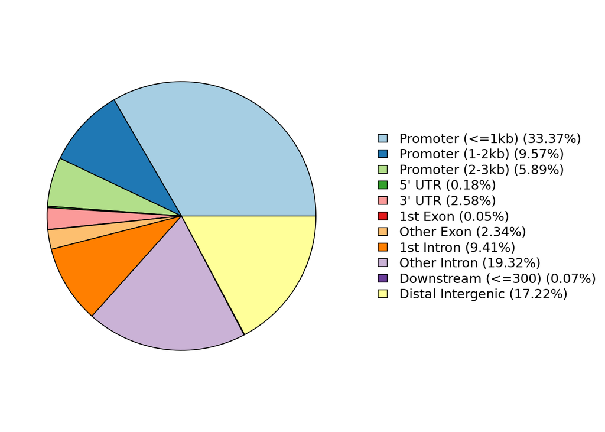

```r
plotAnnoPie(peakAnno)
```

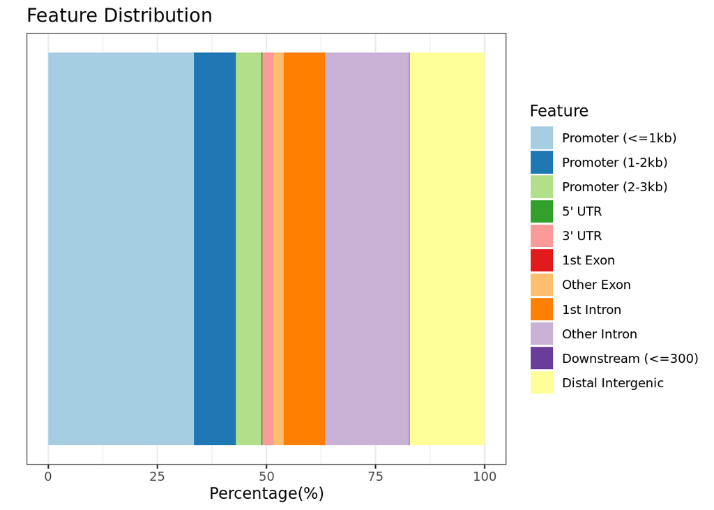

```r
plotAnnoBar(peakAnno)
```

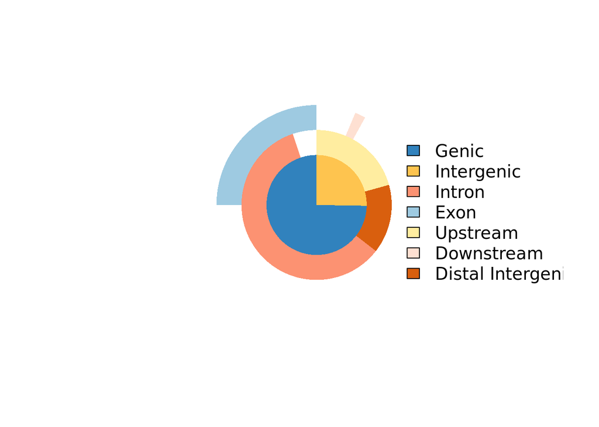

```r
vennpie(peakAnno)
```

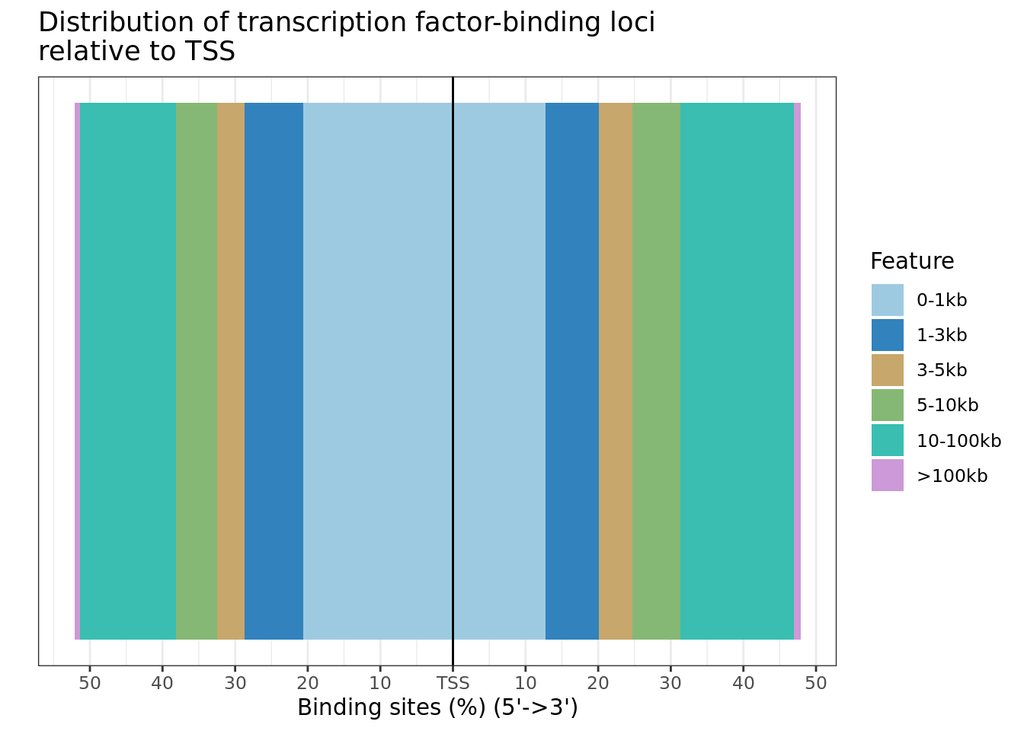

```r
plotDistToTSS(peakAnno,
              title="Distribution of transcription factor-binding loci\nrelative to TSS")
```

# 3. Gene Annotation with biomaRt

```r
Host <- "https://aug2020.archive.ensembl.org"
Specie <- "hsapiens"
BioMart <- biomaRt::listMarts(host=Host)[1,1]
Version <- biomaRt::listMarts(host=Host)[1,2]
Mart <- biomaRt::useMart(host=Host, biomart=BioMart, version=Version,
                         dataset=paste0(Specie,'_gene_ensembl'))

GeneVector = unique(as.data.frame(peakAnno)$geneId) #Genes assigned to the regions by chipseeker

Attributes = c('ensembl_gene_id', 'ensembl_gene_id_version', 'hgnc_symbol', 'external_gene_name', 'gene_biotype',
               'description', 'chromosome_name', 'start_position', 'end_position')

GeneAnnotation <- biomaRt::getBM(mart=Mart, filters='ensembl_gene_id_version', values=GeneVector, attributes=Attributes, uniqueRows=TRUE)
```

```r
GeneAnnotation <- GeneAnnotation[GeneAnnotation$chromosome_name %in% c(1:22, "X", "Y", "MT"),]
GeneAnnotation <- GeneAnnotation %>% dplyr::filter(!duplicated(ensembl_gene_id_version))

if(length(unique(GeneAnnotation$ensembl_gene_id_version)) != length(GeneAnnotation$ensembl_gene_id_version)){
  stop('ERROR: not-unique EnsemblID in annotation!')
}

GeneVector[!GeneVector %in% GeneAnnotation$ensembl_gene_id_version] #ChipSeeker annotation that are not present in the biomart
##  [1] "ENSG00000228572.7_PAR_Y"  "ENSG00000182378.14_PAR_Y" "ENSG00000178605.13_PAR_Y" "ENSG00000226179.6_PAR_Y"  "ENSG00000167393.18_PAR_Y"
##  [6] "ENSG00000275287.5_PAR_Y"  "ENSG00000280767.3_PAR_Y"  "ENSG00000234958.6_PAR_Y"  "ENSG00000229232.6_PAR_Y"  "ENSG00000185960.14_PAR_Y"
## [11] "ENSG00000225661.7_PAR_Y"  "ENSG00000205755.12_PAR_Y" "ENSG00000198223.16_PAR_Y" "ENSG00000185291.12_PAR_Y" "ENSG00000169100.14_PAR_Y"
## [16] "ENSG00000236871.7_PAR_Y"  "ENSG00000236017.8_PAR_Y"  "ENSG00000169093.16_PAR_Y" "ENSG00000182162.11_PAR_Y" "ENSG00000197976.12_PAR_Y"
## [21] "ENSG00000196433.13_PAR_Y" "ENSG00000223511.7_PAR_Y"  "ENSG00000234622.6_PAR_Y"  "ENSG00000169084.15_PAR_Y" "ENSG00000223571.6_PAR_Y"
## [26] "ENSG00000214717.12_PAR_Y" "ENSG00000277120.5_PAR_Y"  "ENSG00000223773.7_PAR_Y"  "ENSG00000230542.6_PAR_Y"  "ENSG00000002586.20_PAR_Y"
## [31] "ENSG00000237801.6_PAR_Y"  "ENSG00000237040.6_PAR_Y"  "ENSG00000124333.16_PAR_Y" "ENSG00000228410.6_PAR_Y"  "ENSG00000124334.17_PAR_Y"
## [36] "ENSG00000270726.6_PAR_Y"
```

```r
AnnotationFinal <- dplyr::left_join(as.data.frame(peakAnno), GeneAnnotation, by=c('geneId' = 'ensembl_gene_id_version'))

AnnotationFinal <- AnnotationFinal %>% rename("ensembl_gene_id_version"="geneId")
```

Here I save gene info

```r
Genes_df <- AnnotationFinal[, c("ensembl_gene_id_version", "ensembl_gene_id", "hgnc_symbol", "gene_biotype")] %>% dplyr::distinct()%>%filter(!is.na(hgnc_symbol))%>%filter(!hgnc_symbol%in%"")
rownames(Genes_df) <- NULL
```

```r
length(Genes_df$hgnc_symbol)
## [1] 36016
```

```r
length(unique(Genes_df$hgnc_symbol))
## [1] 36011
```

```r
Genes_df[Genes_df$hgnc_symbol%in%Genes_df[duplicated(Genes_df$hgnc_symbol), "hgnc_symbol"],]
##       ensembl_gene_id_version ensembl_gene_id hgnc_symbol                       gene_biotype
## 3309        ENSG00000285053.1 ENSG00000285053        TBCE                     protein_coding
## 3310        ENSG00000284770.2 ENSG00000284770        TBCE                     protein_coding
## 20449       ENSG00000237940.3 ENSG00000237940   LINC01238                             lncRNA
## 20451       ENSG00000261186.2 ENSG00000261186   LINC01238                             lncRNA
## 21924      ENSG00000206195.11 ENSG00000206195      DUXAP8                             lncRNA
## 21926       ENSG00000271672.1 ENSG00000271672      DUXAP8   transcribed_processed_pseudogene
## 24581       ENSG00000284862.3 ENSG00000284862      CCDC39                     protein_coding
## 24582      ENSG00000145075.13 ENSG00000145075      CCDC39                             lncRNA
## 30308       ENSG00000272655.2 ENSG00000272655     POLR2J4 transcribed_unprocessed_pseudogene
## 30309       ENSG00000214783.9 ENSG00000214783     POLR2J4                             lncRNA
```

# 4. Saving and session info

```r
saveRDS(AnnotationFinal, paste0(OutputFolder, "TwistAnnotated.rds"))
```

```r
date()
```

```
## [1] "Fri Sep 27 18:59:23 2024"
```